# Exploration of mitigation date, relative contact rate and infectious days

```r
library(dplyr)
library(ggplot2)
library(lubridate)
library(readr)
library(tidyr)
library(stringr)
library(forcats)
```

## Introduction

I wanted to see how sensitive the CHIME projections are to values of the key input variables. Using my sim_chime_scenario_runner tool, I ran 560 scenarios based on the following ranges for each input factor:

- `mitigation-date` : 2020-03-21 through 2020-03-27
- `relative-contact-rate` : 0.05 to 0.80 in 0.05 increments
- `infectious-days` : 8, 9, 10, 11 and 12 days

Here is the config file with values for all of the other inputs:

```
--population 5026226
--market-share 0.30
--current-hospitalized 1059
--date-first-hospitalized 2020-02-20
--mitigation-date 2020-03-21
--current-date 2020-04-08
--relative-contact-rate 0.54
--hospitalized-rate 0.025
--icu-rate 0.0075
--ventilated-rate 0.005
--infectious-days 10
--hospitalized-day 7
--icu-days 9
--ventilated-day 10
--n-days 120
--recovered 0
```

## Data reading and prep

Read in the csv file and do a little data type fixing using the readr package.

```r
adm_cen_long <- read_csv("data/mdrcid_adm_cen_long_df.csv",
    col_types = cols(id = col_integer(),
                     date = col_date(format = "%Y-%m-%d"),
                     mit_date = col_date(format = "%Y-%m-%d")))
# Make scenario a factor
adm_cen_long$scenario <- as.factor(adm_cen_long$scenario)
```

Snoop the data to make sure things look ok.

```r
summary(adm_cen_long)
```

```
##        X1                        scenario            day
##  Min.   :   0   mdrcid_md0321rc10id10:   1859   Min.   :-48
##  1st Qu.: 464   mdrcid_md0321rc10id11:   1859   1st Qu.: -6
##  Median : 929   mdrcid_md0321rc10id12:   1859   Median : 36
##  Mean   : 929   mdrcid_md0321rc10id8 :   1859   Mean   : 36
##  3rd Qu.:1394   mdrcid_md0321rc10id9 :   1859   3rd Qu.: 78
##  Max.   :1858   mdrcid_md0321rc15id10:   1859   Max.   :120
##                 (Other)              :1029886
##       date            dispo_measure          cases
##  Min.   :2020-02-20   Length:1041040     Min.   :    0.0
##  1st Qu.:2020-04-02   Class :character   1st Qu.:    0.2
##  Median :2020-05-14   Mode  :character   Median :   10.3
##  Mean   :2020-05-14                      Mean   :  424.2
##  3rd Qu.:2020-06-25                      3rd Qu.:  143.0
##  Max.   :2020-08-06                      Max.   :22812.9
##                                          NA's   :338800
##     mit_date           rel_con_rate       inf_days
##  Min.   :2020-03-21   Min.   :0.0500   Min.   : 8
##  1st Qu.:2020-03-22   1st Qu.:0.2375   1st Qu.: 9
##  Median :2020-03-24   Median :0.4250   Median :10
##  Mean   :2020-03-24   Mean   :0.4250   Mean   :10
##  3rd Qu.:2020-03-26   3rd Qu.:0.6125   3rd Qu.:11
##  Max.   :2020-03-27   Max.   :0.8000   Max.   :12
##
```

Here are the various measures that were captured.

```r
unique(adm_cen_long$dispo_measure)
```

```
##  [1] "admits_hospitalized" "admits_icu"          "admits_ventilated"
##  [4] "census_hospitalized" "census_icu"          "census_ventilated"
##  [7] "avg_census"          "covid_census"        "covid_admits"
## [10] "covid_discharges"    "covid_deaths"
```

Let’s create a smaller df to work with, just focusing on hospitalized.

```r
hosp_measures <- c("admits_hospitalized", "census_hospitalized",
                   "covid_admits", "covid_census")
```

```r
hosp_long <- adm_cen_long %>%
  filter(dispo_measure %in% hosp_measures ) %>%
  select(2:ncol(adm_cen_long))
```

```r
rm(adm_cen_long)
```

## Hospitalizations

```r
mdrcid_hosp_rmse <- hosp_long %>%
  pivot_wider(names_from = dispo_measure, values_from = cases) %>%
  filter(!is.na(covid_admits)) %>%
  mutate(adm_err = admits_hospitalized - covid_admits,
         cen_err = census_hospitalized - covid_census) %>%
  group_by(scenario, mit_date, rel_con_rate, inf_days) %>%
  summarize(
    adm_rmse = sqrt(sum(adm_err ** 2)),
    cen_rmse = sqrt(sum(cen_err ** 2))
  ) %>%
  arrange(adm_rmse)
```

Build some plot labels.

```r
label <- sprintf("RMSE = %.1f\n", mdrcid_hosp_rmse$adm_rmse)
label <- str_c(label, sprintf("Mit Date = %s\n", format(mdrcid_hosp_rmse$mit_date, "%m-%d")))
label <- str_c(label, sprintf("Contact = %.2f\n", mdrcid_hosp_rmse$rel_con_rate))
label <- str_c(label, sprintf("Inf Days = %.1f\n", mdrcid_hosp_rmse$inf_days))
mdrcid_hosp_rmse$label <- label
```

### Top 20 Fits for admits

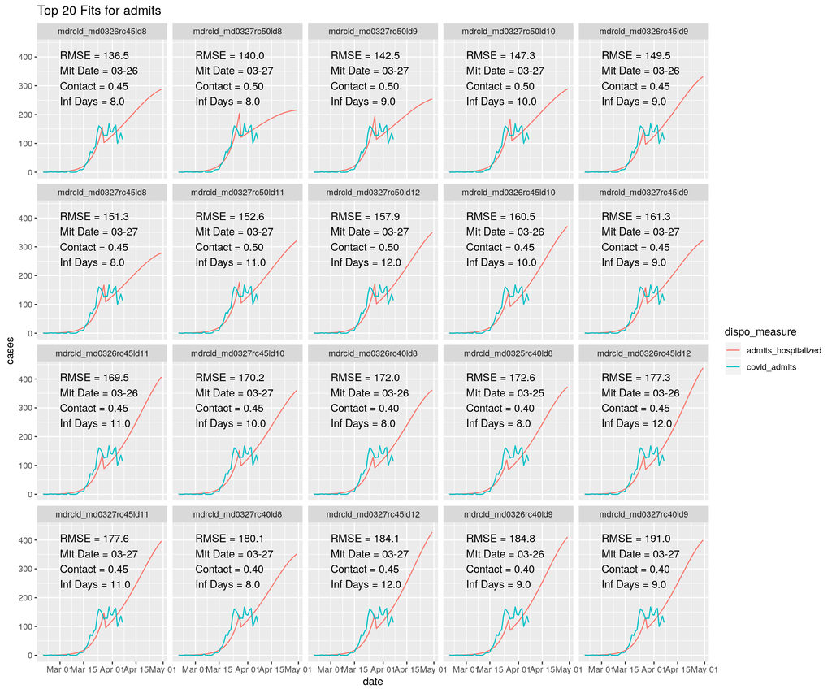

```r
scenario_levels <-mdrcid_hosp_rmse[1:20, ]
scenario_levels$rmse_rank <- 1:20

adm_plot_df <- hosp_long %>%
  filter(scenario %in% scenario_levels$scenario) %>%
  filter(date < as.Date("2020-05-01")) %>%
  filter(dispo_measure %in% c('admits_hospitalized', 'covid_admits')) %>%
  left_join(scenario_levels, by=c("scenario"))

# Reorder the scenario factor by rmse
adm_plot_df$scenario <- as.character(adm_plot_df$scenario)
adm_plot_df$scenario <- as.factor(adm_plot_df$scenario)
adm_plot_df$scenario <- fct_reorder(adm_plot_df$scenario, adm_plot_df$rmse_rank, min)

ggplot(adm_plot_df) +
geom_line(aes(x=date, y=cases, colour=dispo_measure)) +
facet_wrap(~scenario, nrow=4 ) +
geom_text(
    data = scenario_levels,
    mapping = aes(x = as.Date("2020-03-01"), y = 300, label=label),
    hjust = "left"
  ) +
ggtitle("Top 20 Fits for admits")
```

### Some moderate fits

For context, here are scenarios 101-120.

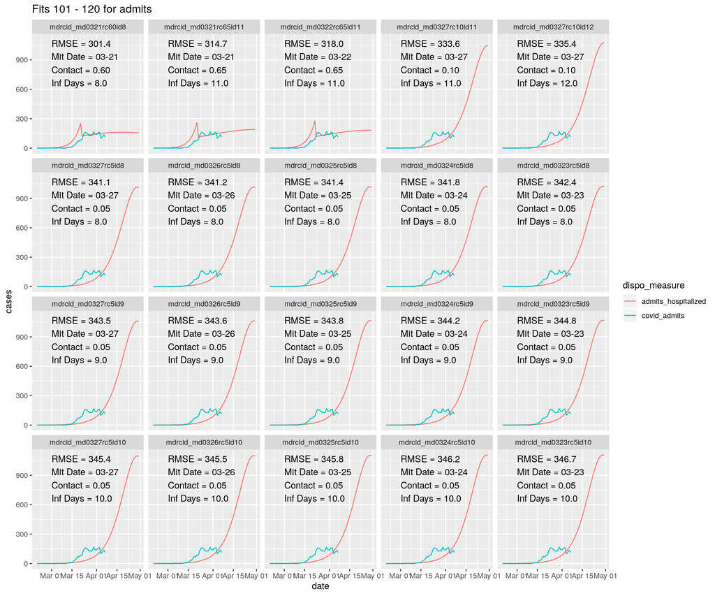

```r
scenario_levels <-mdrcid_hosp_rmse[101:120, ]
scenario_levels$rmse_rank <- 1:20

adm_plot_df <- hosp_long %>%
  filter(scenario %in% scenario_levels$scenario) %>%
  filter(date < as.Date("2020-05-01")) %>%
  filter(dispo_measure %in% c('admits_hospitalized', 'covid_admits')) %>%
  left_join(scenario_levels, by=c("scenario"))

# Reorder the scenario factor by rmse
adm_plot_df$scenario <- as.character(adm_plot_df$scenario)
adm_plot_df$scenario <- as.factor(adm_plot_df$scenario)
adm_plot_df$scenario <- fct_reorder(adm_plot_df$scenario, adm_plot_df$rmse_rank, min)

ggplot(adm_plot_df) +
geom_line(aes(x=date, y=cases, colour=dispo_measure)) +
facet_wrap(~scenario, nrow=4 ) +
geom_text(
    data = scenario_levels,
    mapping = aes(x = as.Date("2020-03-01"), y = 800, label=label),
    hjust = "left"
  ) +
ggtitle("Fits 101 - 120 for admits")
```

### Some poor fits

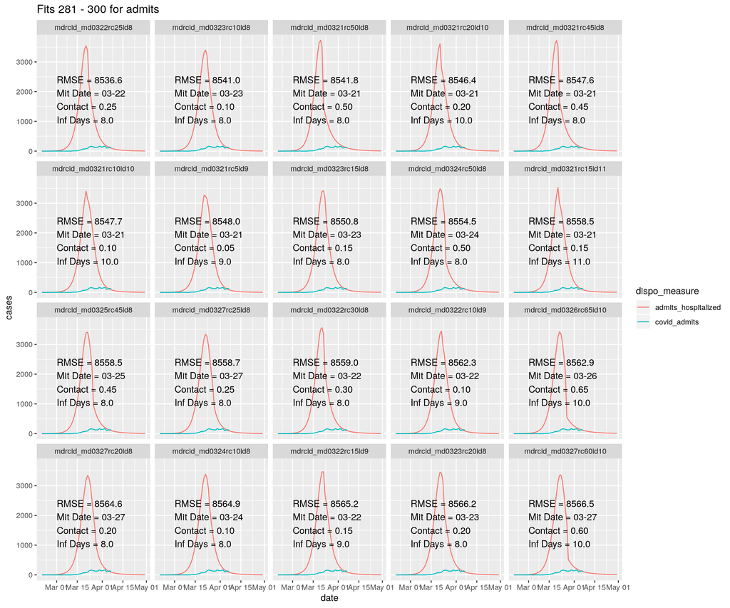

```r
scenario_levels <-mdrcid_hosp_rmse[281:300, ]
scenario_levels$rmse_rank <- 1:20

adm_plot_df <- hosp_long %>%
  filter(scenario %in% scenario_levels$scenario) %>%
  filter(date < as.Date("2020-05-01")) %>%
  filter(dispo_measure %in% c('admits_hospitalized', 'covid_admits')) %>%
  left_join(scenario_levels, by=c("scenario"))

# Reorder the scenario factor by rmse
adm_plot_df$scenario <- as.character(adm_plot_df$scenario)
adm_plot_df$scenario <- as.factor(adm_plot_df$scenario)
adm_plot_df$scenario <- fct_reorder(adm_plot_df$scenario, adm_plot_df$rmse_rank, min)

ggplot(adm_plot_df) +
geom_line(aes(x=date, y=cases, colour=dispo_measure)) +
facet_wrap(~scenario, nrow=4 ) +
geom_text(
    data = scenario_levels,
    mapping = aes(x = as.Date("2020-03-01"), y = 1500, label=label),
    hjust = "left"
  ) +
ggtitle("Fits 281 - 300 for admits")
```

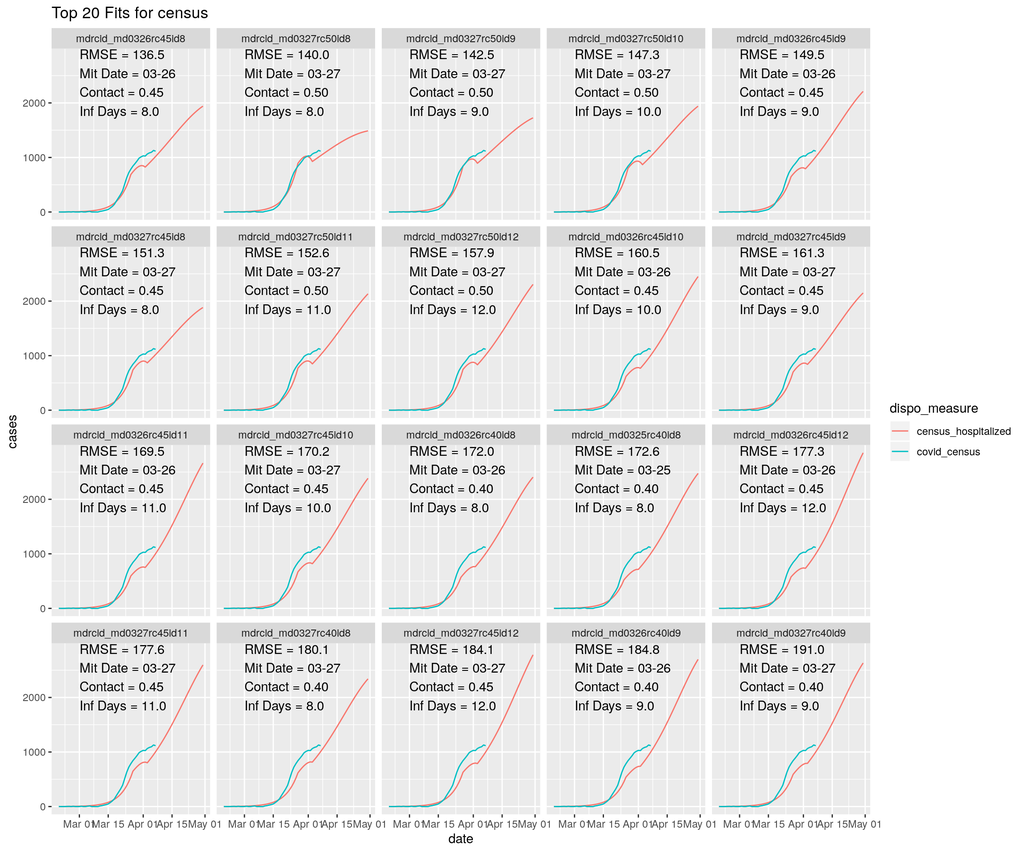

```r
scenario_levels <-mdrcid_hosp_rmse[1:20, ]
scenario_levels$rmse_rank <- 1:20

cen_plot_df <- hosp_long %>%
  filter(scenario %in% scenario_levels$scenario) %>%
  filter(date < as.Date("2020-05-01")) %>%
  filter(dispo_measure %in% c('census_hospitalized', 'covid_census')) %>%
  left_join(scenario_levels, by=c("scenario"))

# Reorder the scenario factor by rmse
cen_plot_df$scenario <- as.character(cen_plot_df$scenario)
cen_plot_df$scenario <- as.factor(cen_plot_df$scenario)
cen_plot_df$scenario <- fct_reorder(cen_plot_df$scenario, cen_plot_df$rmse_rank, min)

ggplot(cen_plot_df) +
geom_line(aes(x=date, y=cases, colour=dispo_measure)) +
facet_wrap(~scenario, nrow=4 ) +
geom_text(
    data = scenario_levels,
    mapping = aes(x = as.Date("2020-03-01"), y = 2200, label=label),
    hjust = "left"
  ) +
ggtitle("Top 20 Fits for census")
```

## Next steps

I’d like to look at market share as well both using a single value and then using the dynamic market share approach.

## Save data

```r
save(hosp_long, mdrcid_hosp_rmse, file = "mdrcid.Rdata")
```